# Introduction to owprm - Occasions within Phases Repeated Measures

W Gregory Alvord

### 1. Introduction

*Repeated measures* data arise in a wide array of different research environments. In this context, …

> The term ‘repeated’ is used here to describe measurements which are made on the same characteristic on the same observational unit but on more than one occasion. (Crowder and Hand, 1990, p. 1)

Because the measurements for a particular individual, subject, patient or observational unit are *repeated*, they are not *independent* within the individual. Therefore, special care must be taken in the statistical analysis of such data.

We analyze some *repeated measures* data taken from the textbook by Crowder and Hand (1990), Example 3.3 on page 32. Twelve hospital patients underwent a dietary regime treatment. Over the course of seven occasions, measurements were taken on ascorbic acid for each patient. The seven occasions were divided into three treatment phases - twice before, thrice during, and twice after the treatment regime. The seven occasions occurred at weeks 1, 2, 6, 10, 14, 15, & 16. The ascorbic acid measurements are made on the *same* patient (subject) over time, and therefore, are not statistically *independent* within the individual patient.

### 2. The Model

For this problem, the model may be written as

$y_{ijk} = \pi_{i} + \Phi_{j} + o_{k(j)} + \pi\Phi_{ij} + \pi o_{ik(j)}$

where $y_{ijk}$ is $ijk^{th}$ response for the $i^{th}$ patient on the $k^{th}$ occasion in the $j^{th}$ phase, $\pi_{i}$ is the $i^{th}$ patient, $\Phi_{j}$ is the $j^{th}$ phase, $o_{k(j)}$ is the $k^{th}$ occasion *nested* within the $j^{th}$ phase, and $\pi o_{ik(j)}$ is the *interaction* between the $i^{th}$ patient and the $k^{th}$ occasion *nested* within the $j^{th}$ phase. In this analysis, the patients (`patient`), occasions (`occ`) and phases (`Phase`) are considered as *factors* in the statistical setup. In particular, the `occ` variable is a *factor* variable, not a *numeric* variable. Therefore, this statistical model is *fully-saturated*. It contains no error term. That is, there is no $\epsilon_{ijk}$ represented in the model. The error term for testing the hypothesis of interest in the `anova` is constructed in a special way, as described in the sequel.

The patient, `patient`, represented as $\pi_{i}$, is a *random* factor. A `patient` is *randomly* selected from a potentially large population of patients. However, `Phase` (Phase) and `occ` (Occasion) are *fixed* factors. They are measured or controlled by the investigator and are comprised of a relatively low number of finite levels. In the model, any interaction between a fixed factor and a random factor is a *random* factor.

In order to test for the hypothesis of whether some relative upward or downward *shift* occurs among `Phase`’s, it is necessary to construct the $F$ statistic in a non-traditional way. To obtain the correct $F$ statistic, it is necessary to generate the *expected mean-squares* from the structural model. The *expected mean-squares* can be derived from different algorithms, such as the *Cornfield-Tukey* algorithm, as outlined, for example, in Winer (1971).

### 3. Plots and Data Description

Figure 1 shows a plot of the data from Crowder and Hand (1990). This plot is constructed from a `groupedData` data frame from package `nlme` (Pinheiro & Bates, 2000). The data appear to show a rise at week 6 and a fall (drop) at week 15.

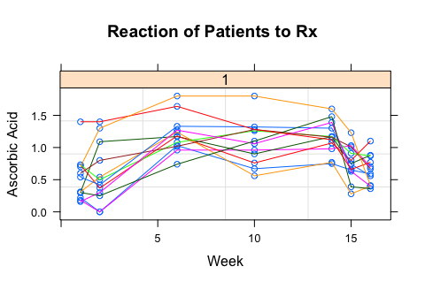

Reaction of twelve `patient`s to treatment (`Rx`) across seven Occasions (`occ`) in three `Phase`s.

Figure 2 shows an alternative plot of the `ascorbic` data, emphasizing that the occasions on the $x$-axis are to be considered as a *factor* dimension as opposed to a *numeric* dimension. This plot is constructed from the `ggplot2` package (Wickham, 2009).

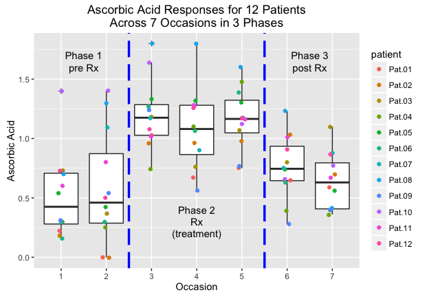

Reaction of twelve `patient`s to treatment (`Rx`) across seven Occasions (`occ`) in three `Phase`s.

On the Occasions axis, the responses are *jittered* to avoid over-plotting. Legends for the patients, `patient`, are included in the plot. For these data, we have three phases, `Phase`, which are designated as `pre`, `Rx`, and `post` to correspond to the respones *before*, *during*, and *after* the treatment regimen. With respect to the spread or *variability* of the data, it appears that the ascorbic acid responses are reasonably homogeneous throughout the seven occasions.

In these analyses, we are interested in detecting `Phase` shifts. The responses appear to be relatively low in the first phase, `pre`. They are followed by an increase in the second phase, `Rx` and then by a drop in the third phase, `post`.

### 4. Analysis

In this problem, there is *one* hypothesis of interest. It is motivated by the question: Is there a difference in the mean levels of responses across the three `Phase`s under consideration, `pre`, `Rx`, and `post`? The criterion variable is ascorbic acid, i.e., `ascorbic.acid` in the `ascorbic` data frame. Here is an abbreviated `anova` (analysis of variance) summary table for this analysis.

```
##               Df Sum Sq Mean Sq
## patient       11  3.682  0.3347
## Phase          2  5.961  2.9805
## occ            4  0.203  0.0509
## patient:Phase 22  2.397  0.1090
## patient:occ   44  2.052  0.0466
```

The correct test for determining whether there is an effect due to `Phase` is constructed by taking the mean square for `Phase` (2.9805) and dividing it by the mean square for `patient:Phase` (0.1090), and entering the $F$ distribution with the appropriate degrees of freedom, shown here. The printing of the probability value to four significant digits is deliberate.

```
##
##       F (null) Num df Den df       p.val
## Value    27.36      2     22 0.000001079
```

### 5. The `owprm` Package

We examine/analyze this problem with the use of the `owprm` package. First load the `owprm` package.

```r
library(owprm)
data(ascorbic)
str(ascorbic)
```

```
## 'data.frame':    84 obs. of  7 variables:
##  $ patient      : Factor w/ 12 levels "Pat.01","Pat.02",..: 1 1 1 1 1 1 1 2 2 2 ...
##  $ week         : num  1 2 6 10 14 15 16 1 2 6 ...
##  $ occ          : Factor w/ 7 levels "1","2","3","4",..: 1 2 3 4 5 6 7 1 2 3 ...
##  $ phase.num    : num  1 1 2 2 2 3 3 1 1 2 ...
##  $ Phase        : Factor w/ 3 levels "post","pre","Rx": 2 2 3 3 3 1 1 2 2 3 ...
##  $ ascorbic.acid: num  0.22 0 1.03 0.67 0.75 0.65 0.59 0.18 0 0.96 ...
##  $ Occasion     : int  1 2 3 4 5 6 7 1 2 3 ...
```

`ascorbic.acid` is the criterion variable of interest. We fit a *fully-saturated* analysis of variance (`aov`) object with the interaction of three `factor` variables, `patient`, `Phase` and `occ`. Next we display the `aovObj`

```r
aovObj <- aov(ascorbic.acid ~ patient*Phase*occ, data = ascorbic)
aovObj
```

```
## Call:
##    aov(formula = ascorbic.acid ~ patient * Phase * occ, data = ascorbic)
##
## Terms:
##                  patient    Phase      occ patient:Phase patient:occ
## Sum of Squares  3.682024 5.961060 0.203488      2.396947    2.052163
## Deg. of Freedom       11        2        4            22          44
##
## 168 out of 252 effects not estimable
## Estimated effects may be unbalanced
```

Before proceeding further, use the `summary` method on the `aovObj`.

```r
summary(aovObj)
```

```
##               Df Sum Sq Mean Sq
## patient       11  3.682  0.3347
## Phase          2  5.961  2.9805
## occ            4  0.203  0.0509
## patient:Phase 22  2.397  0.1090
## patient:occ   44  2.052  0.0466
```

We next apply the `owprm()` function to the `aovObj`. Because the `aovObj` is fully saturated, a warning is printed to the screen.

```r
owprm_aovObj <- owprm(aovObj)
```

```
## Warning in anova.lm(aovObj): ANOVA F-tests on an essentially perfect fit
## are unreliable
```

[output not shown]

[output not shown]

[output not shown]

The warning messages can be avoided by executing the `suppressWarnings()` command. Now display the `owprm_aovObj` object.

```r
owprm_aovObj <- suppressWarnings(owprm(aovObj))
owprm_aovObj
```

```
## Call:
## owprm.default(aovObj = aovObj)
##
## Anova Summary Table for Occ w/in Phases Rep Meas Analy:
##       F (null) Num df Den df        p.val
## Value 27.35632      2     22 1.079227e-06
##
## Summary of Saturated ANOVA Object:
##               Df Sum Sq Mean Sq
## patient       11  3.682  0.3347
## Phase          2  5.961  2.9805
## occ            4  0.203  0.0509
## patient:Phase 22  2.397  0.1090
## patient:occ   44  2.052  0.0466
```

In practice, we are generally most interest in the first `Anova Summary Table for Occ w/in Phases Rep Meas Analy` component. This conveniently provided by the `summary` method applied to the `owprm_aovObj` object.

```r
summary(owprm_aovObj)
```

```
##
##       F (null) Num df Den df        p.val
## Value 27.35632      2     22 1.079227e-06
```

This result may be displayed in a “prettier” form with the following code.

```r
options(digits = 4, scipen = 2)
summary(owprm_aovObj)
```

```
##
##       F (null) Num df Den df       p.val
## Value    27.36      2     22 0.000001079
```

### References

Alvord WG and Carchedi N (2015) ‘Occasions Within Phases Repeated Measures Analysis with Derivation of Expected Mean Squares by the Cornfield-Tukey Algorithm’, https://rpubs.com/ga4247/53980

Cornfield J and Tukey JW (1956) ‘Average values of mean squares in factorials’ *Annals of Mathematical Statistics*, **27**, 907-949.

Crowder MJ and Hand DJ (1990) *Analysis of Repeated Measures*, Chapman and Hall, London.

Del Prete GQ, …, Alvord WG, … Lifson JD (2015) ‘Elevated plasma viral loads in romidepsin treated SIV-infected rhesus macaques on suppressive combination antiretroviral therapy.’ *Antimicrobial Agents and Chemotherapy*, 12/2015; DOI:10.1128/AAC.02625-15.

Del Prete GQ, …, Alvord WG, … Lifson JD (2014) ‘Effect of SAHA administration on the residual virus pool in a model of combination antiretroviral therapy-mediated suppression in SIVmac239-infected Indian rhesus macaques.’ *Antimicrobial Agents and Chemotherapy*, **58**(11), 6790-806.

Pinheiro jC and Bates DM (2000) *Mixed-Effects Models in S and S-Plus*, Springer, New York.

Pinheiro J, Bates D, DebRoy S, Sarkar D and R Core Team (2015). *nlme: Linear and Nonlinear Mixed Effects Models*. R package version 3.1-122, .

Winer BJ (1971) *Statistical Principles in Experimental Design*, 2nd ed., McGraw-Hill.